# Endometriosis Data Analysis

Aditi Nayak

2026-11-05

# 1 Introduction

Endometriosis is a reproductive health condition that can be associated with symptoms such as chronic pelvic pain and menstrual irregularities.

This analysis uses a synthetic endometriosis dataset obtained from Kaggle containing 10,000 simulated observations. The dataset was created to simulate realistic patterns among characteristics and symptoms associated with endometriosis.

The objective of this analysis is to explore characteristics of the dataset and examine how selected reproductive health symptoms differ according to endometriosis diagnosis.

I will begin with summarizing and visualizing the data and variables I want to focus on. Later, I will demonstrate a regression used to examine factors associated with endometriosis diagnosis.

# 2 Data and Methods

## 2.2 Statistical Analysis

I summarized the characteristics of the simulated dataset overall and by endometriosis diagnosis. I also visualized chronic pain levels based on diagnosis. Finally, a logistic model was used to examine the associations between the outcome (endometriosis diagnosis) and various predictors like age, menstrual irregularity, chronic pain level, hormone level abnormality, infertility, and BMI.

# 3 Results

## 3.1 Descriptive Analysis

### 3.1.1 Tabular Analysis

**Table 1. Characteristics of the simulated study population by endometriosis diagnosis**

| **Characteristic** | **Overall** N = 10,000<sup>1</sup> | **No Endometriosis**<sup>1</sup> | **Endometriosis**<sup>1</sup> |
| --- | --- | --- | --- |
| Age | 34 (26, 42) | 34 (26, 42) | 34 (26, 41) |
| Menstrual Irregularity | 6,975 (70%) | 3,915 (66%) | 3,060 (75%) |
| Chronic Pain Level | 5.04 (3.67, 6.40) | 4.85 (3.46, 6.19) | 5.24 (3.99, 6.64) |
| Hormone Level Abnormality | 5,911 (59%) | 3,048 (51%) | 2,863 (70%) |
| Infertility | 2,983 (30%) | 1,550 (26%) | 1,433 (35%) |
| BMI | 23.0 (20.3, 25.7) | 22.8 (20.2, 25.2) | 23.5 (20.6, 26.3) |

<sup>1</sup> Median (Q1, Q3); n (%)

Individuals with endometriosis had higher levels of chronic pain and higher percentages of menstrual irregularity, hormone level abnormality, and infertility compared with individuals without endometriosis. Age was similar between the two groups, while BMI was slightly higher among individuals with endometriosis.

## 3.2 Graphical Analysis

I further examined chronic pain levels to visualize how pain levels differed according to endometriosis diagnosis. Menstrual irregularity is also represented by color to compare pain levels within each diagnosis group.

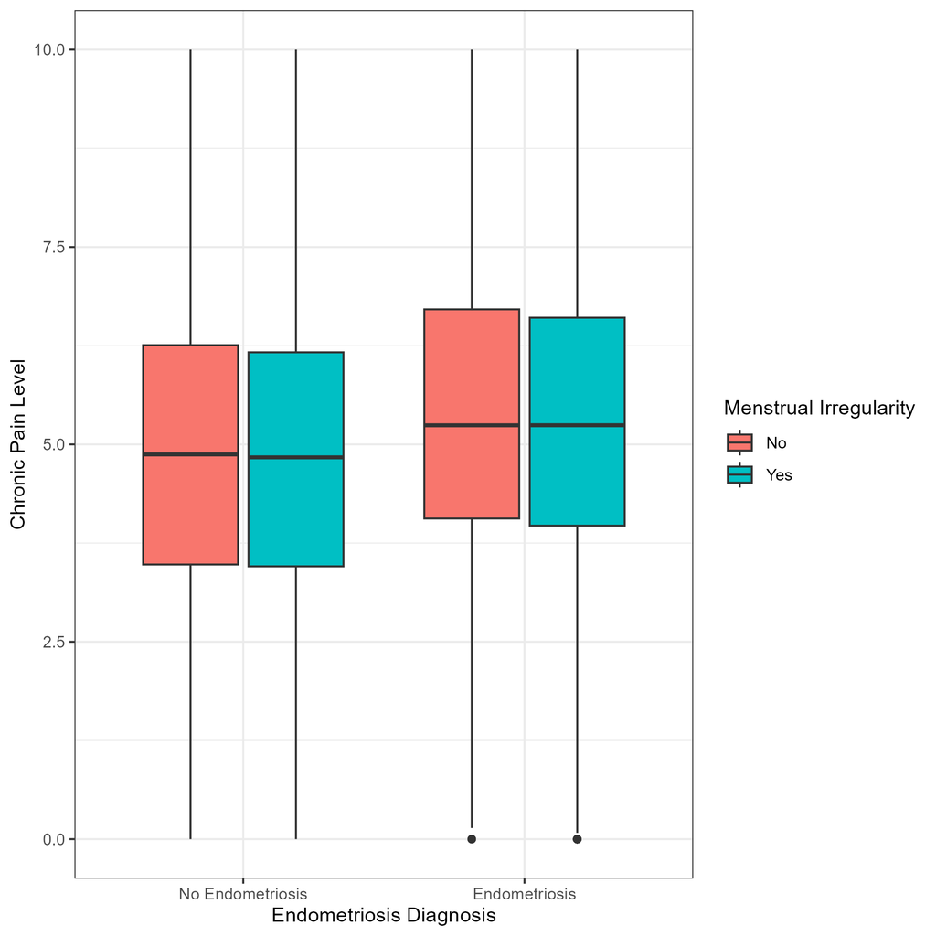

Figure 1. Distribution of chronic pain levels by endometriosis diagnosis and menstrual irregularity.

## 3.3 Logistic Regression Analysis

A logistic regression model was used to examine the associations between the selected demographic and reproductive health characteristics and endometriosis diagnosis.

| **Characteristic** | **OR** | **95% CI** | **p-value** |
| --- | --- | --- | --- |
| Age | 1.00 | 0.99, 1.00 | 0.3 |
| Menstrual Irregularity | 1.57 | 1.43, 1.72 | <0.001 |
| Chronic Pain Level | 1.14 | 1.11, 1.16 | <0.001 |
| Hormone Level Abnormality | 2.28 | 2.10, 2.49 | <0.001 |
| Infertility | 1.56 | 1.43, 1.71 | <0.001 |
| BMI | 1.05 | 1.04, 1.06 | <0.001 |

Abbreviations: CI = Confidence Interval, OR = Odds Ratio

In the logistic regression model, menstrual irregularity, chronic pain level, hormone level abnormality, infertility, and BMI were associated with higher odds of an endometriosis diagnosis. Hormone level abnormality showed the strongest association, with individuals with abnormal hormone levels having 2.28 times the odds of an endometriosis diagnosis compared with individuals with normal hormone levels (95% CI: 2.10–2.49). Age was not associated with endometriosis diagnosis in this model.